# Making Interactive Maps of Public Data in R

Richard Ressler

2020-04-17

# 1 Learning Outcomes

- Create interactive maps in R using publicly available data.
- References:
  - [Ryan Reynolds’s Tutorial](https://civisanalytics.github.io/interactive-map-tutorial/).
  - [Simple Features](https://cran.r-project.org/web/packages/sf/vignettes/sf1.html).
  - [Leaflet](https://rstudio.github.io/leaflet/)
  - [WGS84](https://en.wikipedia.org/wiki/World_Geodetic_System)
  - [OpenStreetMap](https://wiki.openstreetmap.org/wiki/Main_Page)
  - [ESRI](https://www.esri.com/en-us/home) +[rspatial Tutorial](https://www.r-spatial.org//r/2018/10/25/ggplot2-sf.html)
- Create maps of Countries and US entities with rnaturalearth and map packages with ggplot2
- References - This is based on [rspatial tutorial](https://www.r-spatial.org//r/2018/10/25/ggplot2-sf.html)

# 2 Creating a Static Map with ggplot2

## 2.1 Packages

- To access maps of countries of the entire world:
  - Use the console to install the package “rnaturalearth”
  - Also install “rnaturalearthdata”, “lwgeom”, “rgeos”, and “ggspatial”
- Use `ne_countries()` to pull country data and choose the scale (package rnaturalearthhires is necessary for scale = “large”).
- The function can return `sf` classes, as defined in the argument `returnclass=sf`:

  ```r
  library(rnaturalearth)
  library(rnaturalearthdata)
  library(rgeos)
  library(ggspatial)
  library(sf)
  library(lwgeom)
  theme_set(theme_bw())

  world <- ne_countries(scale = "medium", returnclass = "sf")
  class(world)
  ```

  ```
  ## [1] "sf"         "data.frame"
  ```

  _ plot the world with ’world" data frame and `geom_sf()`

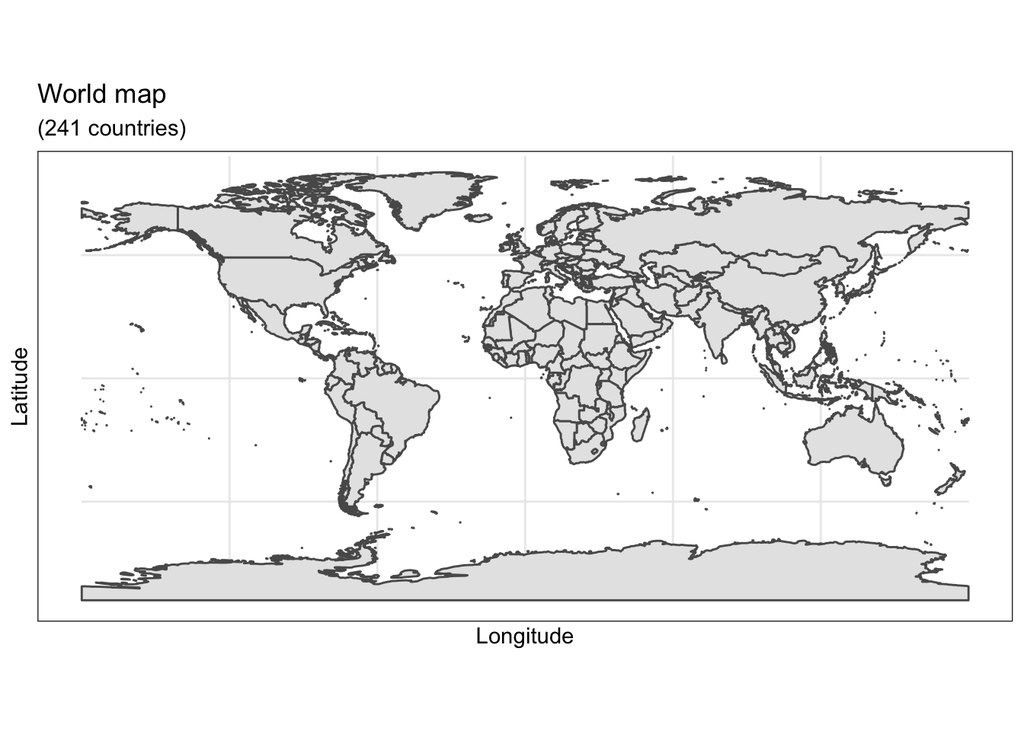

  ```r
  ggplot(data = world) +
    geom_sf() +
  xlab("Longitude") + ylab("Latitude") +
  ggtitle("World map",
          subtitle = paste0("(", length(unique(world$name)), " countries)"))
  ```

- You can use normal fills or more complext ones as well.
  - IN this example,
    - the “viridis” colorblind-friendly palette for the color gradient
    - (with option = “plasma” for the plasma variant),
    - using the square root of the population (`world$pop_est`)

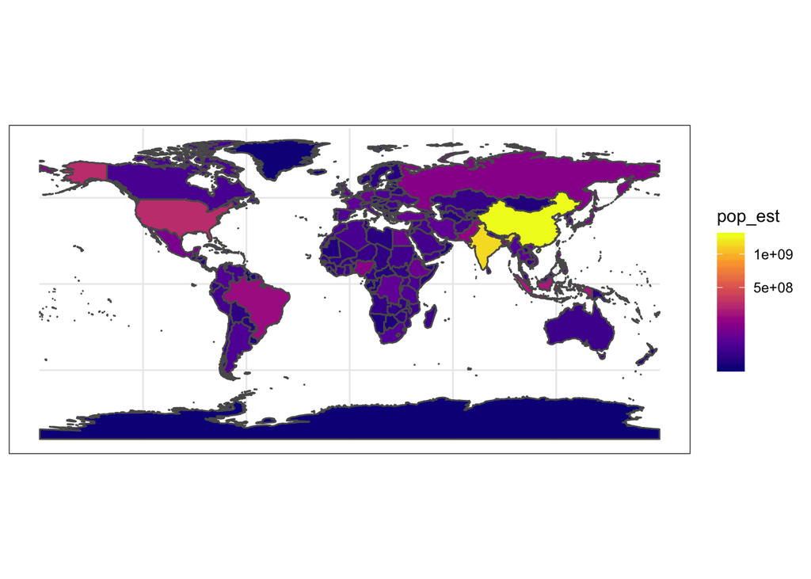

```r
ggplot(data = world) +
    geom_sf(aes(fill = pop_est)) +
    scale_fill_viridis_c(option = "plasma", trans = "sqrt")
```

- The extent of the map can also be set in `coord_sf()`, in practice allowing to “zoom” in the area of interest, provided by limits on the x-axis (xlim), and on the y-axis (ylim).
  - Limits are automatically expanded by a fraction to ensure data and axes don’t overlap;

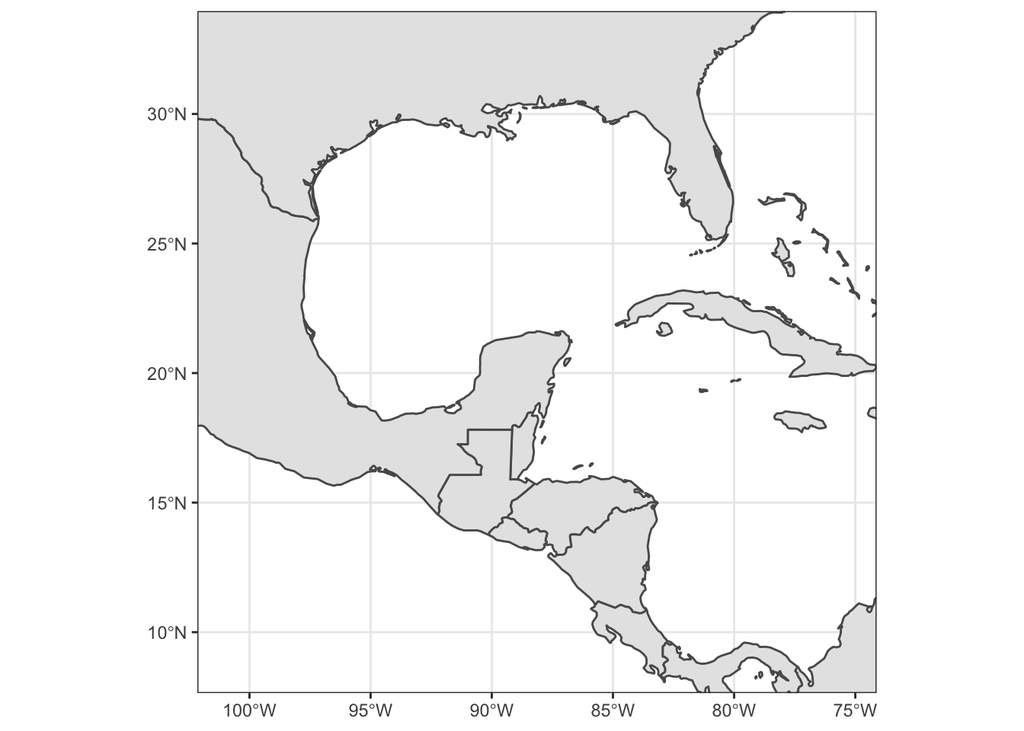

    ```r
    ggplot(data = world) +
        geom_sf() +
        coord_sf(xlim = c(-102.15, -74.12), ylim = c(7.65, 33.97), expand = FALSE)
    ```

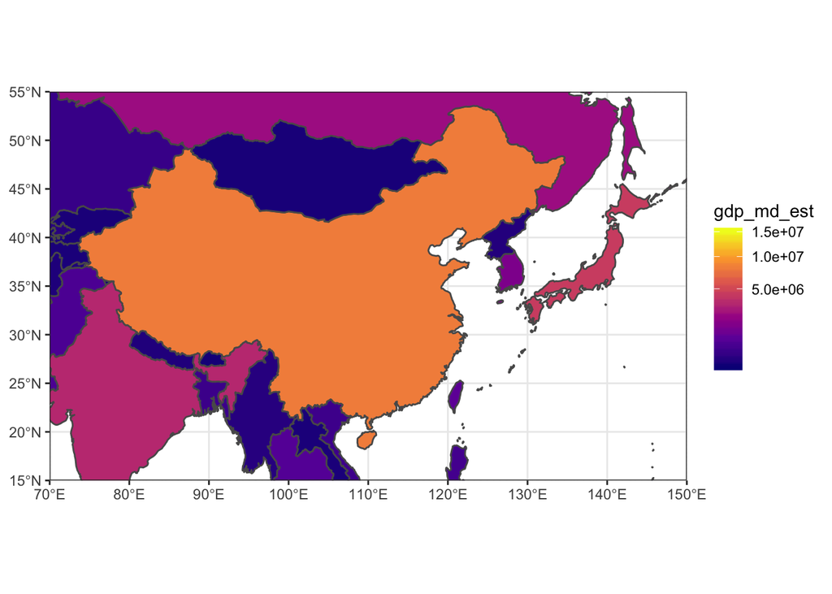

    ```r
    ggplot(data = world) +
        geom_sf(aes(fill = gdp_md_est)) +
        coord_sf(xlim = c(70, 150), ylim = c(15, 55), expand = FALSE) +
        scale_fill_viridis_c(option = "plasma", trans = "sqrt")
    ```

## 2.2 Country names and other names (`geom_text` and `annotate`)

- The world df contains country names and the coordinates of the centroid of each country - - Use `geom_text()` to add a layer of text to a map using geographic coordinates.
  - We have a very flexible control to adjust the text:
  - The size (argument size);
  - The alignment, which is centered by default on the coordinates provided.
  - Adjust horizontally or vertically using the arguments `hjust` and `vjust`, (a number between 0 (right/bottom) and 1 (top/left) or a character (“left”, “middle”, “right”, “bottom”, “center”, “top”).
  - Offset horizontally or vertically with the argument `nudge_x` and `nudge_y`;
  - Set text color with `color`) or the type of font (`fontface`);
  - To control the overlap of labels, use `check_overlap`, which removes overlapping text.
- For the text labels, define the centroid of the counties with `sf::st_centroid`
- Finally, the `annotate()` function can be used to add a single character string at a specific location, as demonstrated here to add the Gulf of Mexico:

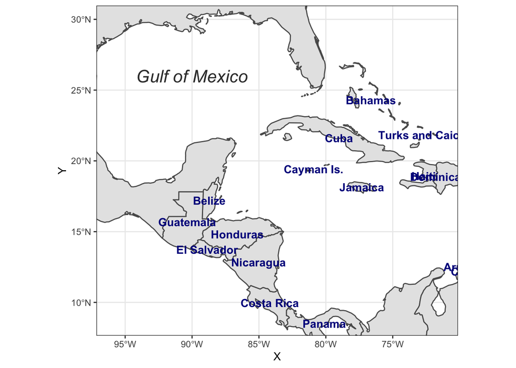

```r
world_points<- st_centroid(world)
world_points <- cbind(world, st_coordinates(st_centroid(world$geometry)))

ggplot(data = world) +
geom_sf() +
geom_text(data= world_points,aes(x=X, y=Y, label=name),
    color = "darkblue", fontface = "bold", check_overlap = FALSE) +
annotate(geom = "text", x = -90, y = 26, label = "Gulf of Mexico",
    fontface = "italic", color = "grey22", size = 6) +
coord_sf(xlim = c(-97.15, -70.12), ylim = c(7.65, 30.97), expand = FALSE)
```

```
## Scale on map varies by more than 10%, scale bar may be inaccurate
```

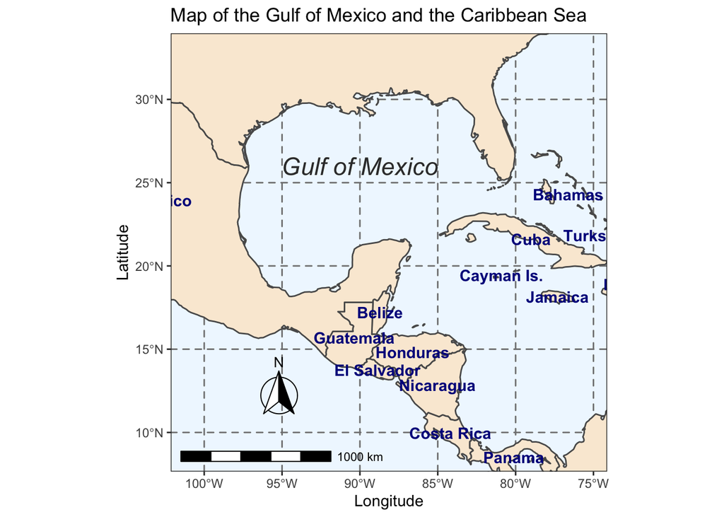

```r
ggplot(data = world) +
  geom_sf(fill= "antiquewhite") +
  geom_text(data= world_points,aes(x=X, y=Y, label=name),
            color = "darkblue", fontface = "bold", check_overlap = FALSE) +
  annotate(geom = "text", x = -90, y = 26, label = "Gulf of Mexico",
           fontface = "italic", color = "grey22", size = 6) +
  annotation_scale(location = "bl", width_hint = 0.5) +
  annotation_north_arrow(location = "bl", which_north = "true",
                         pad_x = unit(0.75, "in"), pad_y = unit(0.5, "in"),
                         style = north_arrow_fancy_orienteering) +
  coord_sf(xlim = c(-102.15, -74.12), ylim = c(7.65, 33.97), expand = FALSE) +
  xlab("Longitude") + ylab("Latitude") +
  ggtitle("Map of the Gulf of Mexico and the Caribbean Sea") +
  theme(panel.grid.major = element_line(color = gray(.5),
                                        linetype = "dashed", size = 0.5),
        panel.background = element_rect(fill = "aliceblue"))
```

## 2.3 Save the map with `ggsave()`

- `ggsave()` allows a graphic to be saved in a variety of formats, including the most common PNG (raster bitmap) and PDF (vector graphics), with control over the size and resolution of the outcome.
- Here we save a PDF version of the map, which keeps the best quality, and a PNG version of it for web purposes:

```r
ggsave("map.pdf")
ggsave("map_web.png", width = 6, height = 6, dpi = "screen")
```

# 3 Adding Data to a Map

## 3.1 Individual Points

- We start by defining two study sites, according to their longitude and latitude, stored in a regular data.frame:

```r
(sites <- data.frame(longitude = c(-80.144005, -80.109), latitude = c(26.479005,
    26.83)))
```

| longitude | latitude |
| --- | --- |
| -80.14401 | 26.47901 |
| -80.10900 | 26.83000 |

- You could use `geom_point()` to adds points but that works on the X, Y scale of the plot, not the map
- Preferred approach is to use functions from the sf package to convert locations to sf objects and handle the conversion between projections.
- That requires entering the projection of the original points as part of the conversion function
- Then you can plot using the map information so the points reeaming even if you cahnge the limits of the map.

```r
(sites <- st_as_sf(sites, coords = c("longitude", "latitude"),
    crs = 4326, agr = "constant"))
```

|  | geometry |
| --- | --- |
| 1 |  |
| 2 |  |

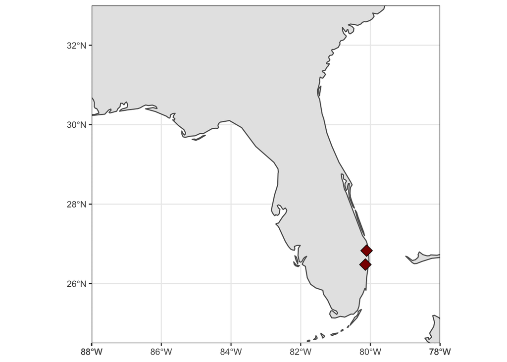

```r
ggplot(data = world) +
    geom_sf() +
    geom_sf(data = sites, size = 4, shape = 23, fill = "darkred") +
    coord_sf(xlim = c(-88, -78), ylim = c(24.5, 33), expand = FALSE)
```

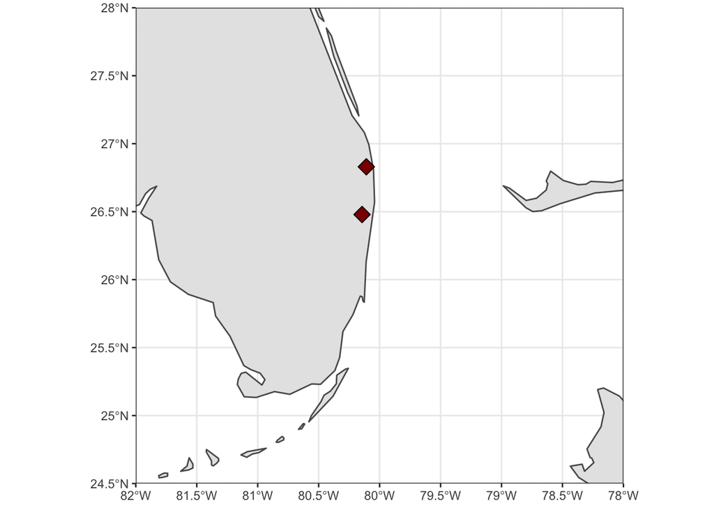

```r
ggplot(data = world) +
    geom_sf() +
    geom_sf(data = sites, size = 4, shape = 23, fill = "darkred") +
    coord_sf(xlim = c(-82, -78), ylim = c(24.5, 28), expand = FALSE)
```

- Note that `coord_sf()`has to be called after all `geom_sf()` calls, as to supersede any former input.

## 3.2 Using package maps to get State, County, and City data

- maps works with ggplot2

```r
library(maps)
states <- st_as_sf(map("state", plot = FALSE, fill = TRUE))
head(states)
```

|  | ID | geom |
| --- | --- | --- |
| 1 | alabama |  |
| 2 | arizona |  |
| 3 | arkansas |  |
| 4 | california |  |
| 5 | colorado |  |
| 6 | connecticut |  |

- State names are part of this data, as the ID variable.
- A simple (but not necessarily optimal) way to add state name is to compute the centroid of each state polygon as the coordinates where to draw their names.
- Centroids are computed with the function `st_centroid`, their coordinates extracted with `st_coordinates`, and attached to the state object:

```r
states <- cbind(states, st_coordinates(st_centroid(states)))
states$ID <- stringr::str_to_title(states$ID)
```

- State data is directly plotted as an additional sf layer using `geom_sf`.
- State names can be added using `geom_text()`, declaring coordinates on the X-axis and Y-axis, as well as the label (from ID), and a relatively big font size.

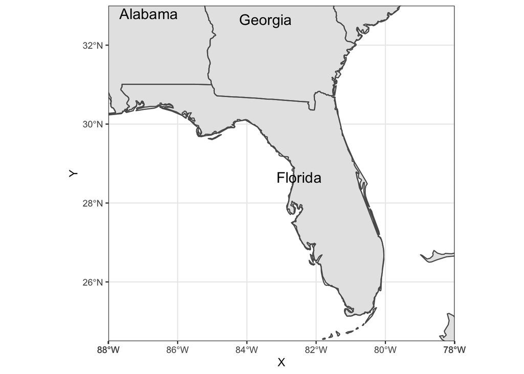

```r
ggplot(data = world) +
    geom_sf() +
    geom_sf(data = states, fill = NA) +
    geom_text(data = states, aes(X, Y, label = ID), size = 5) +
    coord_sf(xlim = c(-88, -78), ylim = c(24.5, 33), expand = FALSE)
```

- Use `nudge_*` to adjust nanes as desired

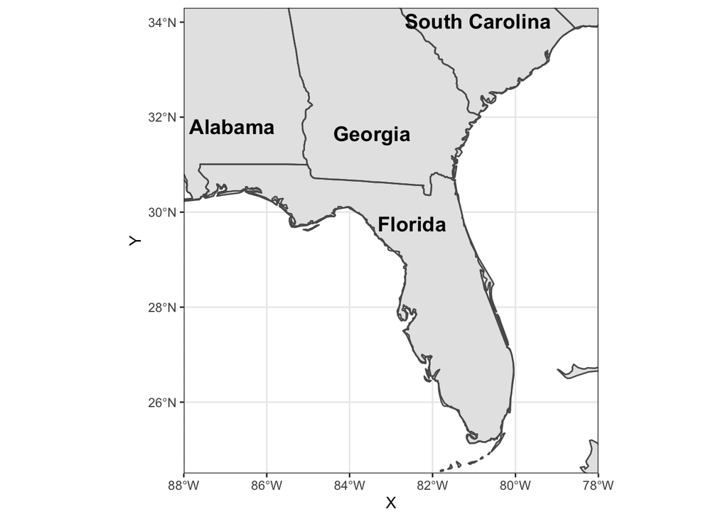

```r
states$nudge_y <- -1
states$nudge_y[states$ID == "Florida"] <- 1.1
states$nudge_y[states$ID == "South Carolina"] <- .1
ggplot(data = world) +
    geom_sf() +
    geom_sf(data = states, fill = NA) +
    geom_text(data = states, aes(X, Y, label = ID), size = 5, fontface = "bold",
        nudge_y = states$nudge_y) +
    coord_sf(xlim = c(-88, -78), ylim = c(24.5, 34.3), expand = FALSE)
```

- We can also get County data from maps, here Florida, color coded by area

```r
counties <- st_as_sf(map("county", plot = FALSE, fill = TRUE))
counties <- subset(counties, grepl("florida", counties$ID))
counties$area <- as.numeric(st_area(counties))
head(counties)
```

|  | ID | geom | area |
| --- | --- | --- | --- |
| 290 | florida,alachua |  | 2498863359 |
| 291 | florida,baker |  | 1542466064 |
| 292 | florida,bay |  | 1946587533 |
| 293 | florida,bradford |  | 818898090 |
| 294 | florida,brevard |  | 2189682999 |
| 295 | florida,broward |  | 3167386973 |

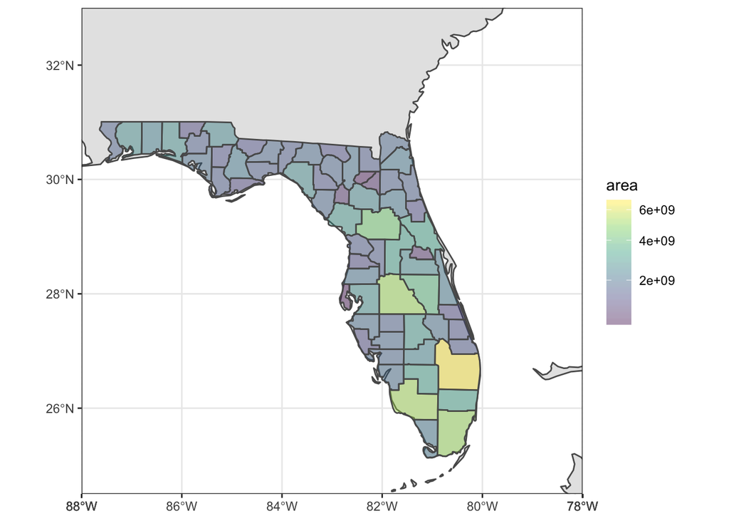

```r
ggplot(data = world) +
    geom_sf() +
    geom_sf(data = counties, aes(fill = area)) +
    scale_fill_viridis_c(trans = "sqrt", alpha = .4) +
    coord_sf(xlim = c(-88, -78), ylim = c(24.5, 33), expand = FALSE)
```

- You can add cities if you know thier latitude and longitude
  - if you have a GoogleMaps API you can use `googleway::geocode()` to find theem
- Add the five largest cities in FLorida to a data frame and convert it to an sf object

  ```r
  flcities <- data.frame(state = rep("Florida", 5), city = c("Miami",
      "Tampa", "Orlando", "Jacksonville", "Sarasota"), lat = c(25.7616798,
      27.950575, 28.5383355, 30.3321838, 27.3364347), lng = c(-80.1917902,
      -82.4571776, -81.3792365, -81.655651, -82.5306527))

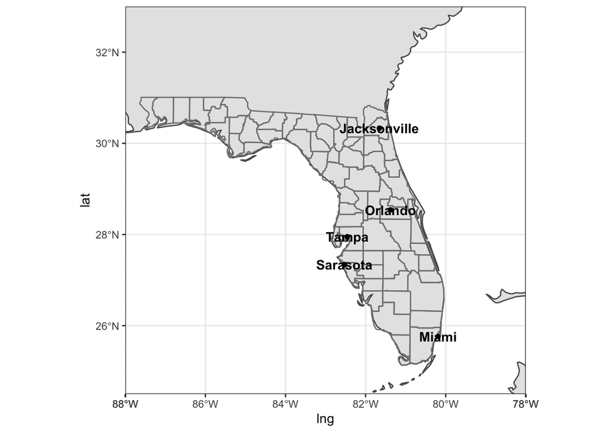

  ```r
  ggplot(data = world) +
  geom_sf() +
  geom_sf(data = counties, fill = NA, color = gray(.5)) +
  geom_sf(data = flcities) +
  geom_text(data = flcities, aes(x = lng, y = lat, label = city),
      size = 3.9, col = "black", fontface = "bold") +
  coord_sf(xlim = c(-88, -78), ylim = c(24.5, 33), expand = FALSE)
  ```

- Use ggrepel package to fix the city name locations

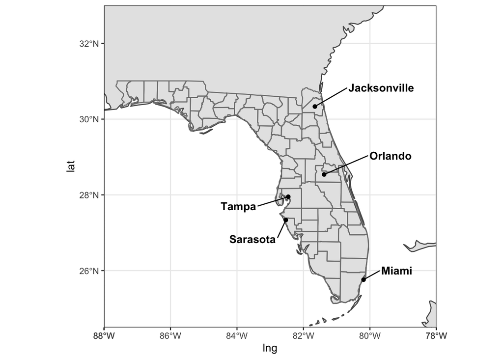

  ```r
  library("ggrepel")
  ggplot(data = world) +
      geom_sf() +
      geom_sf(data = counties, fill = NA, color = gray(.5)) +
      geom_sf(data = flcities) +
      geom_text_repel(data = flcities, aes(x = lng, y = lat, label = city),
          fontface = "bold", nudge_x = c(1, -1.5, 2, 2, -1), nudge_y = c(0.25,
              -0.25, 0.5, 0.5, -0.5)) +
      coord_sf(xlim = c(-88, -78), ylim = c(24.5, 33), expand = FALSE)
  ```

- you can combine the data all together:

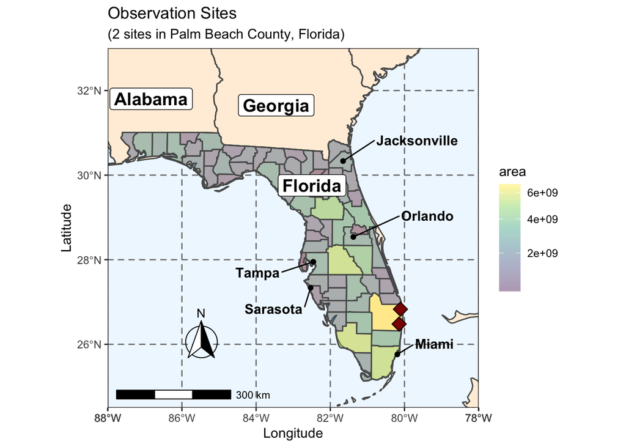

```r
ggplot(data = world) +
    geom_sf(fill = "antiquewhite1") +
    geom_sf(data = counties, aes(fill = area)) +
    geom_sf(data = states, fill = NA) +
    geom_sf(data = sites, size = 4, shape = 23, fill = "darkred") +
    geom_sf(data = flcities) +
    geom_text_repel(data = flcities, aes(x = lng, y = lat, label = city),
        fontface = "bold", nudge_x = c(1, -1.5, 2, 2, -1), nudge_y = c(0.25,
            -0.25, 0.5, 0.5, -0.5)) +
    geom_label(data = states, aes(X, Y, label = ID), size = 5, fontface = "bold",
        nudge_y = states$nudge_y) +
    scale_fill_viridis_c(trans = "sqrt", alpha = .4) +
    annotation_scale(location = "bl", width_hint = 0.4) +
    annotation_north_arrow(location = "bl", which_north = "true",
        pad_x = unit(0.75, "in"), pad_y = unit(0.5, "in"),
        style = north_arrow_fancy_orienteering) +
    coord_sf(xlim = c(-88, -78), ylim = c(24.5, 33), expand = FALSE) +
    xlab("Longitude") + ylab("Latitude") +
    ggtitle("Observation Sites", subtitle = "(2 sites in Palm Beach County, Florida)") +
    theme(panel.grid.major = element_line(color = gray(0.5), linetype = "dashed",
        size = 0.5), panel.background = element_rect(fill = "aliceblue"))
```